# Statistical Inference Course Project Part 1 : Central Limit Theorem using Simulation

Jonathan Lok-Chuen Lo

October 25, 2015

## Overview

In this project, I will investigate the exponential distribution in R and compare it with the Central Limit Theorem. The exponential distribution is used and simulated in R with `rexp(n, lambda)` where lambda is the rate parameter. I will investigate the distribution of 40 exponentials and set lambda = 0.2. The simulated mean and standard deviation will be compared against the theoretical values to illustrate the Central Limit Theorem.

## Simulations

Generate the simulated data from exponential distribution with lambda = 0.2 and number of exponentials = 40. A thousand simulations is produced, and hence total of 40,000 simulated data is required (i.e. 1000 * 40 exponentials each).

```r
# Initialise the seed to ensure reproducibility
set.seed(8)

# Parameters for the simulation
n <- 40
lambda <- 0.2
numSimulations <- 1000

# Generate the simulated data and compare the sample mean and variance
simulatedData <- matrix(rexp(n * numSimulations, lambda), numSimulations, n)
simulatedDataMean <- apply(simulatedData, 1, mean)
simulatedDataVar <- apply(simulatedData, 1, var)
```

## Sample Mean versus Theoretical Mean

Calculate the average sample mean and compare it against the theoretical mean of exponential distribution (which is equal to 1/lambda).

```r
sampleMean <- mean(simulatedDataMean)
theoreticalMean <- 1 / lambda
cbind(sampleMean, theoreticalMean)
```

```
##      sampleMean theoreticalMean
## [1,]   5.006442               5
```

Tha sample mean is **5.0064** while the theoretical mean is **5**. This shows the sample mean is a very good estimate of the theoretical mean of the distribution.

Below plots the historgram of the sample mean distribution, with the average sample mean and the theoretical mean shown. Again, this shows the average sample mean is very close to the theoretical value.

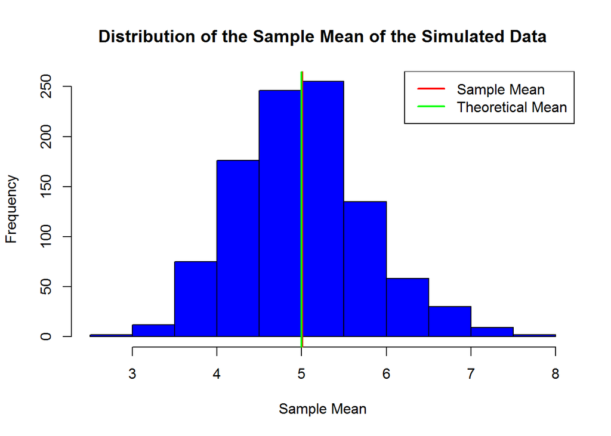

Calculate the average sample variance and compare it against the theoretical variance of exponential distribution (which is equal to (1/lambda)^2).

```r
sampleVar <- mean(simulatedDataVar)
theoreticalVar <- (1 / lambda)^2
cbind(sampleVar, theoreticalVar)
```

```
##      sampleVar theoreticalVar
## [1,]  25.10708             25
```

Tha sample variance is **25.1071** while the theoretical variance is **25**. This shows the sample variance is a very good estimate of the theoretical mean of the distribution.

Below plots the historgram of the sample variance distribution, with the average sample variance and the theoretical variance shown.

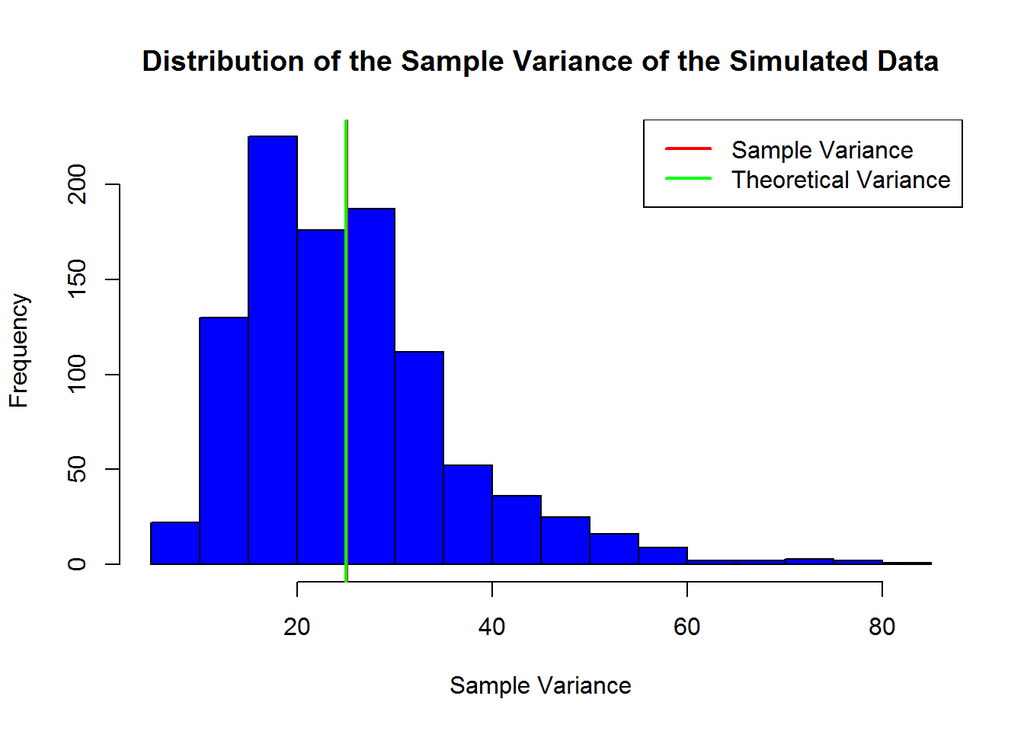

## Distribution

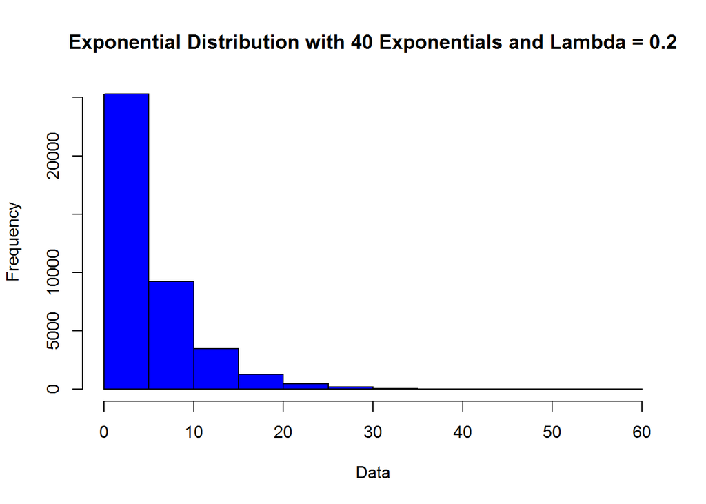

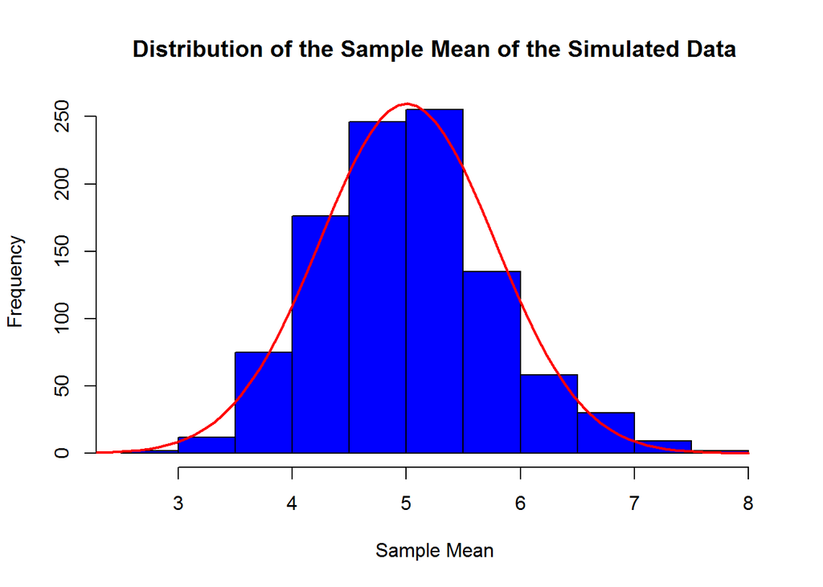